# Reproducible Research Project 1

David R. Cote

6/23/2020

The data for this assignment can be downloaded from the course web site:

Dataset: Activity monitoring data [52K]  
https://d396qusza40orc.cloudfront.net/repdata%2Fdata%2Factivity.zip

The variables included in this dataset are:

steps: Number of steps taking in a 5-minute interval (missing values are coded as NA)  
date: The date on which the measurement was taken in YYYY-MM-DD format  
interval: Identifier for the 5-minute interval in which measurement was taken  
The dataset is stored in a comma-separated-value (CSV) file and there are a total of 17,568 observations in this dataset.

Loading Libraries:

```r
library(data.table)
library(ggplot2)
library(knitr)
```

Loading Data:

```r
fileUrl <-  "https://d396qusza40orc.cloudfront.net/repdata%2Fdata%2Factivity.zip"
download.file(fileUrl,destfile=paste0(getwd(),'/repdata%2Fdata%2Factivity.zip'), method = "curl")
unzip("repdata%2Fdata%2Factivity.zip")
```

Create Data Table:

```r
ActivityData <- data.table::fread(input = "activity.csv")
```

Format Dates in Table:

```r
ActivityData[, date := as.POSIXct(date, format = "%Y-%m-%d")]
```

## Question A: What is mean total number of steps taken per day?

### 1. Calculate the total number of steps taken per day

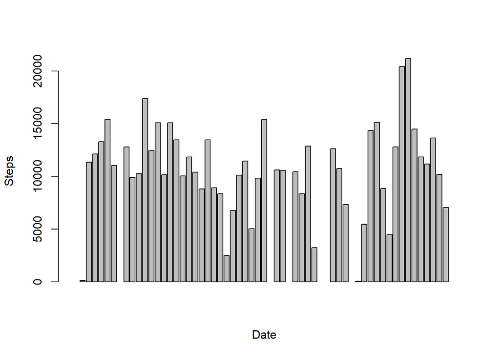

```r
Daily_Steps <- ActivityData[, c(lapply(.SD, sum, na.rm = FALSE)), .SDcols = c("steps"), by = .(date)]
barplot(Daily_Steps$steps,xlab="Date",ylab="Steps")
```

### 2. Make a histogram of the total number of steps taken each day

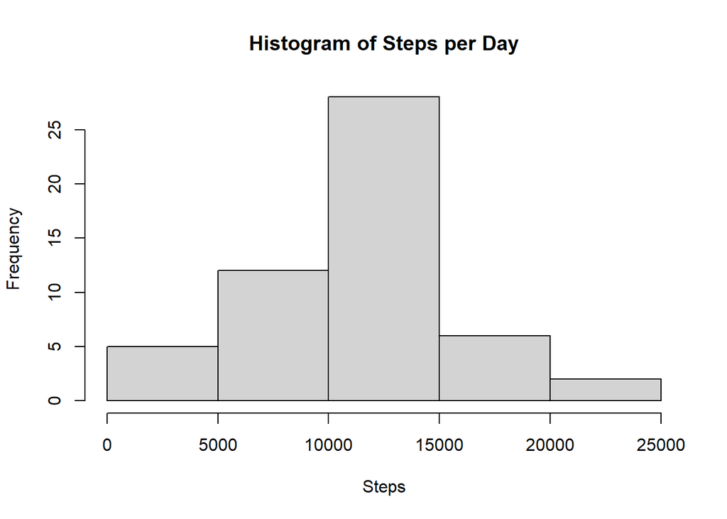

```r
hist(Daily_Steps$steps,xlab="Steps",breaks=5,main="Histogram of Steps per Day")
```

### 3. Calculate and report the mean and median of the total number of steps taken per day

```r
Daily_Steps[, .(Mean_Steps = mean(steps, na.rm = TRUE), Median_Steps = median(steps, na.rm = TRUE))]
```

```
##    Mean_Steps Median_Steps
## 1:   10766.19        10765
```

## Question B: What is the average daily activity pattern?

### 1. Make a time series plot of the 5-minute interval (x-axis) and the average number of steps taken, averaged across all days (y-axis)

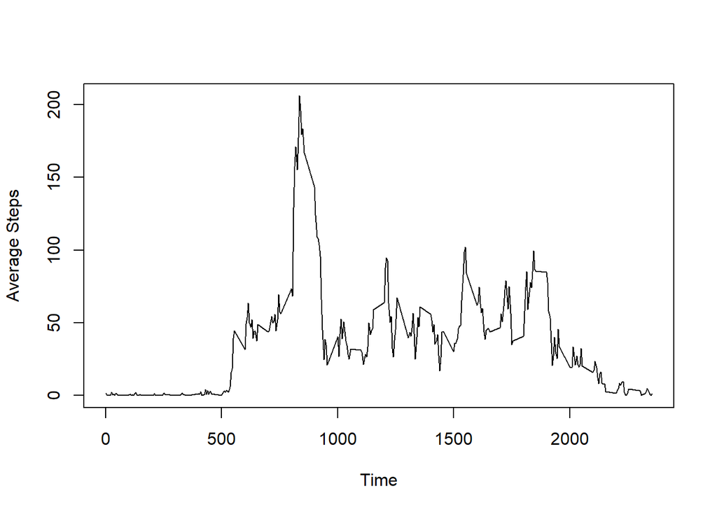

```r
Interval_Steps <- ActivityData[, c(lapply(.SD, mean, na.rm = TRUE)), .SDcols = c("steps"), by = .(interval)]
plot(Interval_Steps$interval,Interval_Steps$steps, type="l",xlab="Time",ylab="Average Steps")
```

### 2. Which 5-minute interval, on average across all the days in the dataset, contains the maximum number of steps?

```r
Interval_Steps[steps == max(steps), .(max_interval = interval)]
```

```
##    max_interval
## 1:          835
```

## Question C: Missing Values

### 1. Calculate and report the total number of missing values in the dataset

```r
ActivityData[is.na(steps), .N ]
```

```
## [1] 2304
```

### 3. Create a new dataset that is equal to the original dataset but with the missing data filled in.

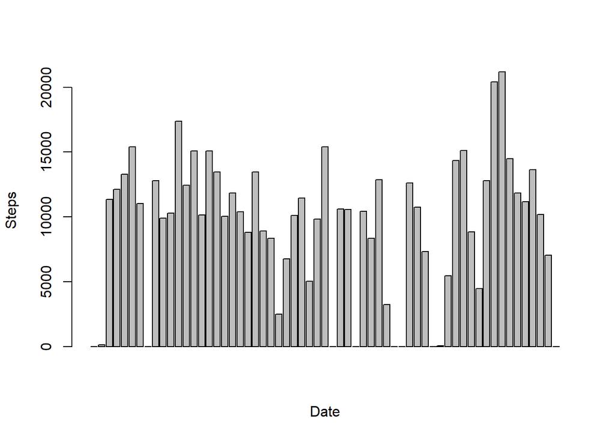

```r
ActivityDataNoNull <- ActivityData
ActivityDataNoNull[is.na(steps), "steps"] <- ActivityDataNoNull[, c(lapply(.SD, median, na.rm = TRUE)), .SDcols = c("steps")]
Daily_Steps_No_Null <- ActivityDataNoNull[, c(lapply(.SD, sum, na.rm = FALSE)), .SDcols = c("steps"), by = .(date)]
Interval_Steps_No_Null <- ActivityDataNoNull[, c(lapply(.SD, mean, na.rm = TRUE)), .SDcols = c("steps"), by = .(interval)]
barplot(Daily_Steps_No_Null$steps,xlab="Date",ylab="Steps")
```

### 4. Make a histogram of the total number of steps taken each day and Calculate and report the mean and median total number of steps taken per day. Do these values differ from the estimates from the first part of the assignment? What is the impact of imputing missing data on the estimates of the total daily number of steps?

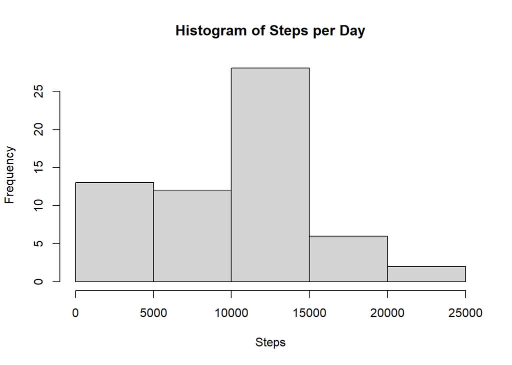

```r
Daily_Steps_No_Null <- ActivityDataNoNull[, c(lapply(.SD, sum, na.rm = FALSE)), .SDcols = c("steps"), by = .(date)]
hist(Daily_Steps_No_Null$steps,xlab="Steps",breaks=5,main="Histogram of Steps per Day")
```

```r
Daily_Steps_No_Null[, .(Mean_Steps_No_Null = mean(steps, na.rm = TRUE), Median_Steps_No_Null = median(steps, na.rm = TRUE))]
```

```
##    Mean_Steps_No_Null Median_Steps_No_Null
## 1:            9354.23                10395
```

## Question D: Are there differences in activity patterns between weekdays and weekends?

### 1. Create a new factor variable in the dataset with two levels – “weekday” and “weekend” indicating whether a given date is a weekday or weekend day.

```r
ActivityData[, `Weekday`:= weekdays(x = date)]
ActivityData[grepl(pattern = "Monday|Tuesday|Wednesday|Thursday|Friday", x = `Weekday`), "Weekdayend"] <- "Weekday"
ActivityData[grepl(pattern = "Saturday|Sunday", x = `Weekday`), "Weekdayend"] <- "Weekend"
ActivityData[, `Weekdayend` := as.factor(`Weekdayend`)]
ActivityDataNoNull[, `Weekday`:= weekdays(x = date)]
ActivityDataNoNull[grepl(pattern = "Monday|Tuesday|Wednesday|Thursday|Friday", x = `Weekday`), "Weekdayend"] <- "Weekday"
ActivityDataNoNull[grepl(pattern = "Saturday|Sunday", x = `Weekday`), "Weekdayend"] <- "Weekend"
ActivityDataNoNull[, `Weekdayend` := as.factor(`Weekdayend`)]
Daily_Steps_No_Null <- ActivityDataNoNull[, c(lapply(.SD, sum, na.rm = FALSE)), .SDcols = c("steps"), by = .(date)]
```

### Make a panel plot containing a time series plot (i.e. type = “l”) of the 5-minute interval (x-axis) and the average number of steps taken, averaged across all weekday days or weekend days (y-axis). See the README file in the GitHub repository to see an example of what this plot should look like using simulated data.

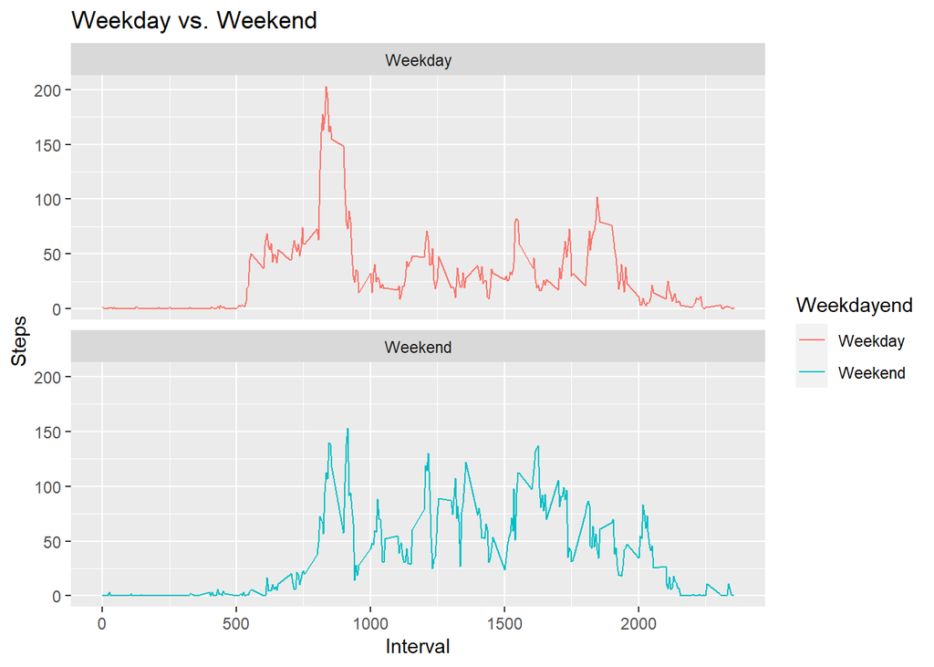

```r
Interval_Steps_No_Null <- ActivityDataNoNull[, c(lapply(.SD, mean, na.rm = TRUE)), .SDcols = c("steps"), by = .(interval, `Weekdayend`)]
ggplot(Interval_Steps_No_Null , aes(x = interval , y = steps, color=`Weekdayend`)) + geom_line() + labs(title = "Weekday vs. Weekend", x = "Interval", y = "Steps") + facet_wrap(~`Weekdayend` , ncol = 1, nrow=2)
```

#### Weekday activity seems dominated by a burst of early morning activity followed by lesser activity for the duration of the day. Weekends have a more moderate level of activity throughout the waking hours.